How to Data

# How to graph a two-variable function as a surface

## Description

Assume we have a mathematical formula in the variables $x$ and $y$ and we would like to plot a graph of it using a 3D coordinate system.

Related tasks:

- How to graph mathematical functions
- How to graph mathematical sequences

## Using SymPy, in Python

View this solution alone.

This answer assumes you have imported SymPy as follows.

```python
from sympy import *                   # load all math functions
init_printing( use_latex='mathjax' )  # use pretty math output
```

First, we need a two-variable function that we wish to plot.

```python
var( 'x y' )
formula = sin( x**2 + y**2 )
formula
```

$\displaystyle \sin{\left(x^{2} + y^{2} \right)}$

You can use `plot3d`, but you have to import it specifically, because it is not imported by default with the rest of SymPy.

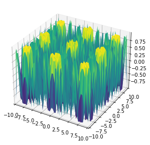

```python
from sympy.plotting.plot import plot3d
plot3d( formula )
```

```
<sympy.plotting.plot.Plot at 0x7f76ca409280>
```

Specify the minimum and maximum values for both $x$ and $y$ as follows. In this example, I keep $-\pi\leq x\leq\pi$ and $-\frac\pi2\leq y\leq\frac\pi2$.

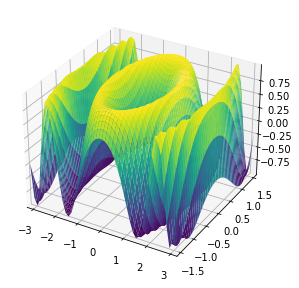

```python
plot3d( formula, (x,-pi,pi), (y,-pi/2,pi/2) )
```

```
<sympy.plotting.plot.Plot at 0x7f763acebd30>
```

Content last modified on 01 June 2021.

See a problem? [Tell us](https://github.com/nathancarter/how2data/issues/new/choose) or edit the source.

## Topics that include this task

- Bentley University GR526

## Opportunities

This website does not yet contain a solution for this task in any of the following software packages.

- R
- Excel

If you can contribute a solution using any of these pieces of software, see our Contributing page for how to help extend this website.